# Prosper Loan Dataset

## Preliminary Wrangling

> This Data set contains 113937 records and 81 columns. which includes loan status, prosper score and many more this factors will be helpfull for evaluating the credit score of a person which will help in future to provide a loan to person based on score. out of 81 columns only 31 have been selected for the analysis.

```python
#import the necessary packages
import numpy as np
import pandas as pd
import matplotlib.pyplot as plt
import seaborn as sb

%matplotlib inline
```

**importing the dataset**

```python
raw_data = pd.read_csv('D:/Study/Online courses/udacity/Data Anlayst/prosperLoanData.csv')
raw_data.head()
```

|  | ListingKey | ListingNumber | ListingCreationDate | CreditGrade | Term | LoanStatus | ClosedDate | BorrowerAPR | BorrowerRate | LenderYield | ... | LP_ServiceFees | LP_CollectionFees | LP_GrossPrincipalLoss | LP_NetPrincipalLoss | LP_NonPrincipalRecoverypayments | PercentFunded | Recommendations | InvestmentFromFriendsCount | InvestmentFromFriendsAmount | Investors |
| --- | --- | --- | --- | --- | --- | --- | --- | --- | --- | --- | --- | --- | --- | --- | --- | --- | --- | --- | --- | --- | --- |
| 0 | 1021339766868145413AB3B | 193129 | 2007-08-26 19:09:29.263000000 | C | 36 | Completed | 2009-08-14 00:00:00 | 0.16516 | 0.1580 | 0.1380 | ... | -133.18 | 0.0 | 0.0 | 0.0 | 0.0 | 1.0 | 0 | 0 | 0.0 | 258 |
| 1 | 10273602499503308B223C1 | 1209647 | 2014-02-27 08:28:07.900000000 | NaN | 36 | Current | NaN | 0.12016 | 0.0920 | 0.0820 | ... | 0.00 | 0.0 | 0.0 | 0.0 | 0.0 | 1.0 | 0 | 0 | 0.0 | 1 |
| 2 | 0EE9337825851032864889A | 81716 | 2007-01-05 15:00:47.090000000 | HR | 36 | Completed | 2009-12-17 00:00:00 | 0.28269 | 0.2750 | 0.2400 | ... | -24.20 | 0.0 | 0.0 | 0.0 | 0.0 | 1.0 | 0 | 0 | 0.0 | 41 |
| 3 | 0EF5356002482715299901A | 658116 | 2012-10-22 11:02:35.010000000 | NaN | 36 | Current | NaN | 0.12528 | 0.0974 | 0.0874 | ... | -108.01 | 0.0 | 0.0 | 0.0 | 0.0 | 1.0 | 0 | 0 | 0.0 | 158 |
| 4 | 0F023589499656230C5E3E2 | 909464 | 2013-09-14 18:38:39.097000000 | NaN | 36 | Current | NaN | 0.24614 | 0.2085 | 0.1985 | ... | -60.27 | 0.0 | 0.0 | 0.0 | 0.0 | 1.0 | 0 | 0 | 0.0 | 20 |

5 rows × 81 columns

```python
print(raw_data.shape)
```

```
(113937, 81)
```

**There are 113,937 records and 81 columns, we can select only the interesting columns to analyze.**

```python
#selecting only necessary columns and droping thr remaining columns
df_loans = raw_data.loc[:,('ListingCreationDate',
                          'DateCreditPulled',
                          'Term',
                          'LoanStatus',
                          'ClosedDate',
                          'BorrowerAPR',
                          'BorrowerRate',
                          'LenderYield',
                          'ProsperRating (Alpha)',
                          'ProsperScore',
                          'ListingCategory (numeric)',
                          'BorrowerState',
                          'Occupation',
                          'EmploymentStatus',
                          'IsBorrowerHomeowner',
                          'AmountDelinquent',
                          'DebtToIncomeRatio',
                          'IncomeRange',
                          'IncomeVerifiable',
                          'StatedMonthlyIncome',
                          'LoanCurrentDaysDelinquent',
                          'LoanFirstDefaultedCycleNumber',
                          'LoanMonthsSinceOrigination',
                          'LoanOriginalAmount',
                          'LoanOriginationDate',
                          'LoanOriginationQuarter',
                          'MonthlyLoanPayment',
                          'LP_ServiceFees',
                          'LP_CollectionFees',
                          'PercentFunded',
                          'Investors' ) ]
```

```python
df_loans.info()
```

```
<class 'pandas.core.frame.DataFrame'>
RangeIndex: 113937 entries, 0 to 113936
Data columns (total 31 columns):
 #   Column                         Non-Null Count   Dtype
---  ------                         --------------   -----
 0   ListingCreationDate            113937 non-null  object
 1   DateCreditPulled               113937 non-null  object
 2   Term                           113937 non-null  int64
 3   LoanStatus                     113937 non-null  object
 4   ClosedDate                     55089 non-null   object
 5   BorrowerAPR                    113912 non-null  float64
 6   BorrowerRate                   113937 non-null  float64
 7   LenderYield                    113937 non-null  float64
 8   ProsperRating (Alpha)          84853 non-null   object
 9   ProsperScore                   84853 non-null   float64
```

[output cut: 23 more lines]

**let's make a copy of data set and change type of date time columns**

```python
#Make a copy of the data frame
df_loans_clean = df_loans.copy()
#Adjust Datetime columns
df_loans_clean.ListingCreationDate = pd.to_datetime(df_loans_clean.ListingCreationDate)
df_loans_clean.DateCreditPulled = pd.to_datetime(df_loans_clean.DateCreditPulled)
df_loans_clean.ClosedDate = pd.to_datetime(df_loans_clean.ClosedDate)
df_loans_clean.LoanOriginationDate = pd.to_datetime(df_loans_clean.LoanOriginationDate)
df_loans_clean.info()
```

```
<class 'pandas.core.frame.DataFrame'>
RangeIndex: 113937 entries, 0 to 113936
Data columns (total 31 columns):
 #   Column                         Non-Null Count   Dtype
---  ------                         --------------   -----
 0   ListingCreationDate            113937 non-null  datetime64[ns]
 1   DateCreditPulled               113937 non-null  datetime64[ns]
 2   Term                           113937 non-null  int64
 3   LoanStatus                     113937 non-null  object
 4   ClosedDate                     55089 non-null   datetime64[ns]
 5   BorrowerAPR                    113912 non-null  float64
 6   BorrowerRate                   113937 non-null  float64
 7   LenderYield                    113937 non-null  float64
 8   ProsperRating (Alpha)          84853 non-null   object
 9   ProsperScore                   84853 non-null   float64
```

[output cut: 23 more lines]

**renaming the column prospeRating (alpha) and listing category (numeric) to appropriate name**

```python
#Rename columns
df_loans_clean = df_loans_clean.rename(columns={'ListingCategory (numeric)': 'ListingCategory',\
                                                'ProsperRating (Alpha)': 'ProsperRating'})
```

```python
# Convert ProsperRating & IncomeRange to ordinal categorical
ordinal_var_dict = {'ProsperRating': ['N/A','HR','E','D','C', 'B', 'A', 'AA'],\
                    'IncomeRange':['$0','$1-24,999','$25,000-49,999','$50,000-74,999','$75,000-99,999','$100,000+']}

for var in ordinal_var_dict:
    ordered_var = pd.api.types.CategoricalDtype(ordered = True,
                                                categories = ordinal_var_dict[var])
    df_loans_clean[var] = df_loans_clean[var].astype(ordered_var)
```

The category of the listing that the borrower selected when posting their listing:

0 - Not Available, 1 - Debt Consolidation, 2 - Home Improvement, 3 - Business, 4 - Personal Loan, 5 - Student Use, 6 - Auto, 7- Other, 8 - Baby&Adoption, 9 - Boat, 10 - Cosmetic Procedure, 11 - Engagement Ring, 12 - Green Loans, 13 - Household Expenses, 14 - Large Purchases, 15 - Medical/Dental, 16 - Motorcycle, 17 - RV, 18 - Taxes, 19 - Vacation, 20 - Wedding Loans

```python
#Replace listing category number by name
cat_num_name = {0:  'Not Available', 1 : 'Debt Consolidation', 2 : 'Home Improvement', 3 : 'Business', 4 : 'Personal Loan',\
                5 : 'Student Use', 6 : 'Auto', 7 : 'Other', 8 : 'Baby&Adoption', 9 : 'Boat', 10 : 'Cosmetic Procedure',\
                11 : 'Engagement Ring', 12 : 'Green Loans', 13 : 'Household Expenses', 14 : 'Large Purchases',\
                15 : 'Medical/Dental', 16 : 'Motorcycle', 17 : 'RV', 18 : 'Taxes', 19 : 'Vacation', 20 : 'Wedding Loans'}

df_loans_clean['ListingCategory'] = df_loans_clean['ListingCategory'].map(cat_num_name)
```

```python
#Adjust datatype for all other categorical columns
df_loans_clean.Occupation = df_loans_clean.Occupation.astype('category')
df_loans_clean.BorrowerState = df_loans_clean.BorrowerState.astype('category')
df_loans_clean.LoanStatus = df_loans_clean.LoanStatus.astype('category')
df_loans_clean.ListingCategory = df_loans_clean.ListingCategory.astype('category')
df_loans_clean.EmploymentStatus = df_loans_clean.EmploymentStatus.astype('category')
```

```python
df_loans_clean.info()
```

```
<class 'pandas.core.frame.DataFrame'>
RangeIndex: 113937 entries, 0 to 113936
Data columns (total 31 columns):
 #   Column                         Non-Null Count   Dtype
---  ------                         --------------   -----
 0   ListingCreationDate            113937 non-null  datetime64[ns]
 1   DateCreditPulled               113937 non-null  datetime64[ns]
 2   Term                           113937 non-null  int64
 3   LoanStatus                     113937 non-null  category
 4   ClosedDate                     55089 non-null   datetime64[ns]
 5   BorrowerAPR                    113912 non-null  float64
 6   BorrowerRate                   113937 non-null  float64
 7   LenderYield                    113937 non-null  float64
 8   ProsperRating                  84853 non-null   category
 9   ProsperScore                   84853 non-null   float64
```

[output cut: 23 more lines]

```python
#Saving the clean data
df_loans_clean.to_csv('df_loans_master.csv', index=False)
```

```python
print(df_loans_clean.shape)
```

```
(113937, 31)
```

### What is the structure of your dataset?

> After removing the unnecessary columns what left is 113937 record and 31 columns

### What features in the dataset do you think will help support your investigation into your feature(s) of interest?

> Loan stauts, StatedMonthlyIncome and Employment status will play a huge importance in supporting the prosperscore

**Univarate Analysis**

numerical variables

```python
#Checking loans' term
df_loans_clean.Term.value_counts()
```

```
36    87778
60    24545
12     1614
Name: Term, dtype: int64
```

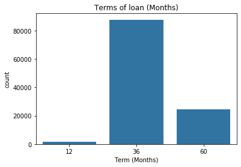

```python
base_color = sb.color_palette()[0]
sb.countplot(data=df_loans_clean,x= 'Term',color=base_color);
plt.title('Terms of loan (Months)')
plt.xlabel('Term (Months)');
```

**from above it is that the loan term is for 1,3,5 years. the people have taken more loans for the period of 3 years, and very few for a year.**

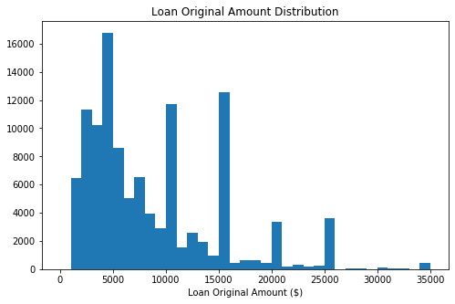

```python
# Loan Original Amount Distribution
binsize = 1000
bins = np.arange(0, df_loans_clean['LoanOriginalAmount'].max()+binsize, binsize)

plt.figure(figsize=[8, 5])
plt.hist(data = df_loans_clean, x = 'LoanOriginalAmount', bins = bins)
plt.xlabel('Loan Original Amount ($)')
plt.title('Loan Original Amount Distribution')
plt.show()
```

their is a long tail distribution and it is hard to interpret so lets plot this graph using the log

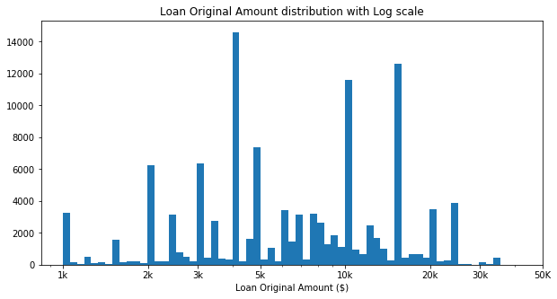

```python
# Putting it in a log-scale
log_binsize = 0.025
bins = 10 ** np.arange(3, np.log10(df_loans_clean['LoanOriginalAmount'].max())+log_binsize, log_binsize)

plt.figure(figsize=[10, 5])
plt.hist(data = df_loans_clean, x = 'LoanOriginalAmount', bins = bins)
plt.xscale('log')
plt.xticks([1e3, 2e3, 3e3, 5e3, 1e4, 2e4, 3e4, 5e4], ['1k', '2k','3k', '5k', '10k', '20k', '30k', '50K'])
plt.xlabel('Loan Original Amount ($)')
plt.title('Loan Original Amount distribution with Log scale')
plt.show()
```

now its better, we can see their is a peak in between the 3K and 5K

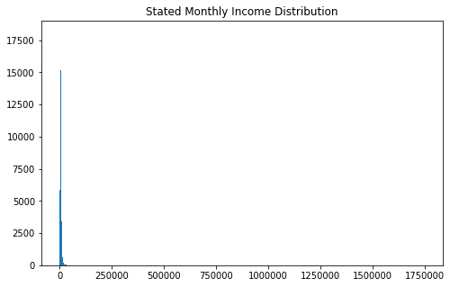

```python
# Stated Monthly income distribution
binsize = 1000
bins = np.arange(0, df_loans_clean['StatedMonthlyIncome'].max()+binsize, binsize)

plt.figure(figsize=[8, 5])
plt.hist(data = df_loans_clean, x = 'StatedMonthlyIncome', bins = bins)
plt.title('Stated Monthly Income Distribution')
plt.show()
```

not a single thing is understandable due to high skewness and the far outliers above the 1000,000 so, lets see it in log-scale

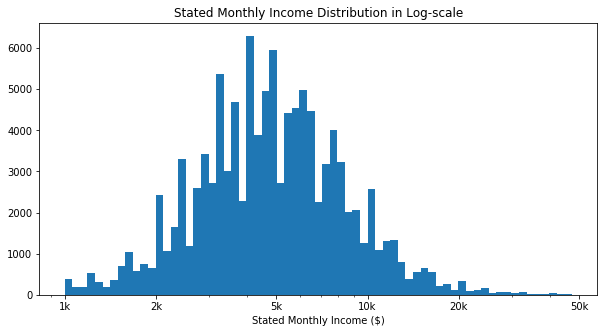

```python
log_binsize = 0.025
bins = 10 ** np.arange(3, 4.7, log_binsize)

plt.figure(figsize=[10, 5])
plt.hist(data = df_loans_clean, x = 'StatedMonthlyIncome', bins = bins)
plt.xscale('log')
plt.xticks([1e3, 2e3, 5e3, 1e4, 2e4, 5e4], ['1k', '2k','5k', '10k', '20k', '50k'])
plt.xlabel('Stated Monthly Income ($)')
plt.title('Stated Monthly Income Distribution in Log-scale')
plt.show()
```

Graph is much more interesting now, almost normal distribution of income.Interesting to see the peak around $5K

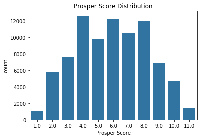

```python
#Prosper Score Distribution
base_color = sb.color_palette()[0]
sb.countplot(data=df_loans_clean,x= 'ProsperScore',color=base_color)
plt.title('Prosper Score Distribution')
plt.xlabel('Prosper Score');
```

Prosper score of value 4 and 6 are the most common Prosper Scores are almost normally distributed

Categorical variabe.

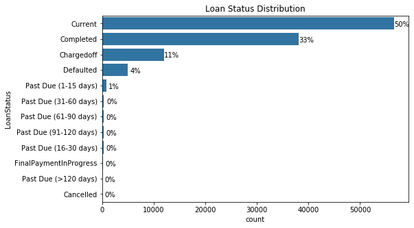

```python
# Loan Status Distribution
status_order = df_loans_clean['LoanStatus'].value_counts().index

plt.figure(figsize=[8, 5])
sb.countplot(data=df_loans_clean,y='LoanStatus',color=base_color,order=status_order);
plt.title('Loan Status Distribution')

# add annotations
n_points = df_loans_clean.shape[0]
cat_counts = df_loans_clean['LoanStatus'].value_counts()
locs, labels = plt.yticks() # get the current tick locations and labels

# loop through each pair of locations and labels
for loc, label in zip(locs, labels):

    # get the text property for the label to get the correct count
    count = cat_counts[label.get_text()]
    pct_string = '{:0.0f}%'.format(100*count/n_points)

    # print the annotation just below the top of the bar
    plt.text(count+1500, loc+0.2,  pct_string, ha = 'center', color = 'black');
```

from the above fig most of the loans status are current and only 33% of people have completed their loan and 4% are noticed as defaulted

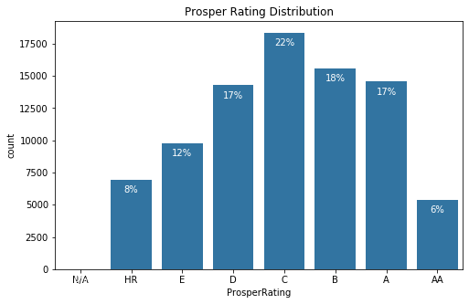

```python
#Prosper Rating Distribution

plt.figure(figsize=[8, 5])
sb.countplot(data=df_loans_clean,x='ProsperRating',color=base_color);
plt.title('Prosper Rating Distribution')

# add annotations
n_points = df_loans_clean[df_loans_clean.ProsperRating.isna() == False].shape[0]
cat_counts = df_loans_clean['ProsperRating'].value_counts()
locs, labels = plt.xticks() # get the current tick locations and labels

# loop through each pair of locations and labels
for loc, label in zip(locs, labels):

    # get the text property for the label to get the correct count
    count = cat_counts[label.get_text()]
    pct_string = '{:0.0f}%'.format(100*count/n_points)

    # print the annotation just below the top of the bar
    plt.text(loc,  count-1000, pct_string, ha = 'center', color = 'w');
```

Most borrowers get Prosper Rating of 'C'

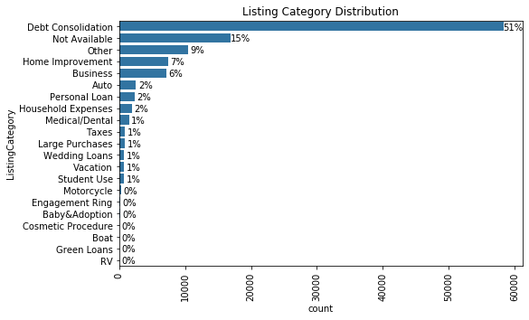

```python
#Listing Category Distrobution
cat_order = df_loans_clean.ListingCategory.value_counts().index
plt.figure(figsize=[8, 5])
sb.countplot(data=df_loans_clean,y='ListingCategory',color=base_color, order=cat_order);
plt.title('Listing Category Distribution')
plt.xticks(rotation=90)

# add annotations
n_points = df_loans_clean.shape[0]
cat_counts = df_loans_clean['ListingCategory'].value_counts()
locs, labels = plt.yticks() # get the current tick locations and labels

# loop through each pair of locations and labels
for loc, label in zip(locs, labels):

    # get the text property for the label to get the correct count
    count = cat_counts[label.get_text()]
    pct_string = '{:0.0f}%'.format(100*count/n_points)

    # print the annotation just below the top of the bar
    plt.text(count+1400, loc+0.3,  pct_string, ha = 'center', color = 'black');
```

the most loans were taken for paying other Debts

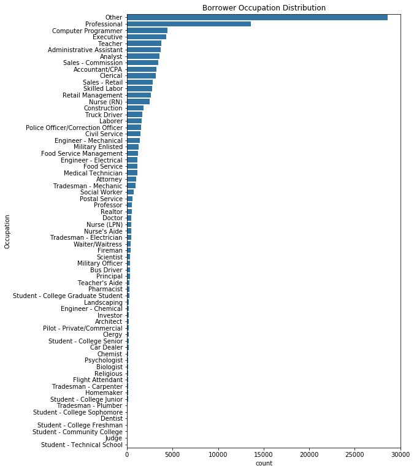

```python
#Borrower Occupation Distrobution
cat_order = df_loans_clean.Occupation.value_counts().index
plt.figure(figsize=[8, 13])
sb.countplot(data=df_loans_clean,y='Occupation',color=base_color, order=cat_order);
plt.title('Borrower Occupation Distribution');
```

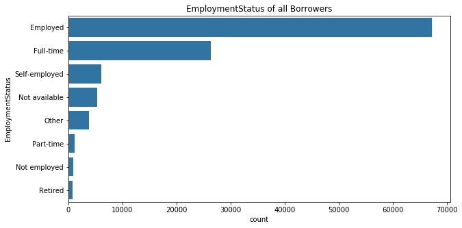

```python
plt.figure(figsize = [10, 5])
base_color = sb.color_palette()[0]
plt.title("EmploymentStatus of all Borrowers")
sb.countplot(data = df_loans_clean, y = 'EmploymentStatus', color = base_color,
             order = df_loans_clean['EmploymentStatus'].value_counts().index);
```

most loans taken are employed

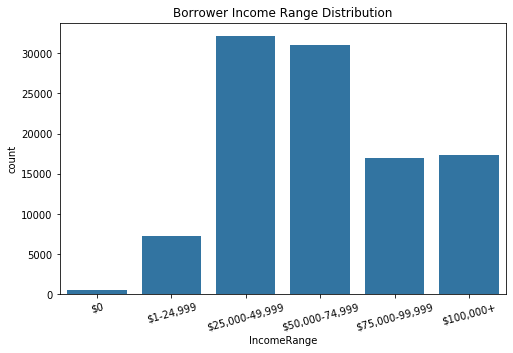

```python
#Borrower Income Range Status Distrobution
plt.figure(figsize=[8, 5])
sb.countplot(data=df_loans_clean,x='IncomeRange',color=base_color);
plt.title('Borrower Income Range Distribution')
plt.xticks(rotation=15);
```

The most income of people lies between 25K to 74K.

### Discuss the distribution(s) of your variable(s) of interest. Were there any unusual points? Did you need to perform any transformations?

> There was no need for any transformations other that changing the data types of some variables. Also, after plotting, it was found that some features should be changed to 'Categorical' like IncomeRange. It was noticed there are some outliers in the StatedMonthlyIncome that are too far away from most of the values, in some charts these outliers are igonred by limiting the axis values.

### Of the features you investigated, were there any unusual distributions? Did you perform any operations on the data to tidy, adjust, or change the form of the data? If so, why did you do this?

> Some features had long-tailed, skewed distributions, these were checked on a log-scale which revealed the hidden distribution in some areas.

### Bivariate analysis

> To investigate variables in pairs, we need to identify numeric and categorical features in order to select the proper chart type.

```python
#Create lists for numeric and categorical variables
numeric_vars =['Term', 'BorrowerAPR', 'LenderYield', 'ProsperScore', 'AmountDelinquent', 'DebtToIncomeRatio',\
               'StatedMonthlyIncome','LoanCurrentDaysDelinquent', 'LoanOriginalAmount', 'MonthlyLoanPayment',\
               'LP_ServiceFees', 'Investors']
categoric_vars = ['LoanStatus', 'ProsperRating', 'ListingCategory', 'BorrowerState', 'Occupation', 'EmploymentStatus',\
                  'IncomeRange']
```

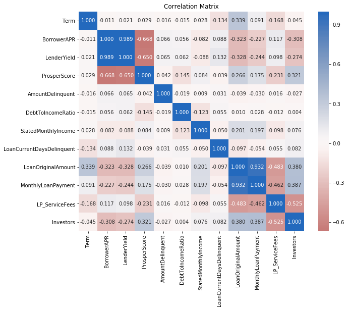

```python
# Correlation matrix for all numeric variables
plt.figure(figsize = [10, 8])
sb.heatmap(df_loans_clean[numeric_vars].corr(), annot = True, fmt = '.3f',
           cmap = 'vlag_r', center = 0)
plt.title('Correlation Matrix')
plt.margins(x = 0.5, y= 0.3)
plt.show()
```

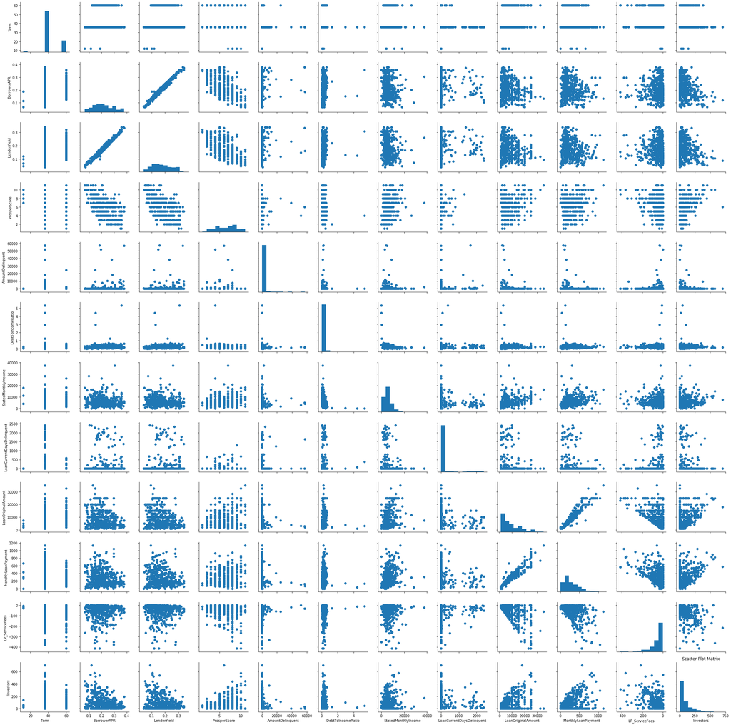

```python
# Taking a sample of 500 loans
samples = np.random.choice(df_loans_clean.shape[0], 500, replace = False)
loans_samp = df_loans_clean.loc[samples,:]

# Building a grid of scatter plots
g = sb.PairGrid(data = loans_samp, vars = numeric_vars)
g.map_offdiag(plt.scatter)
g = g.map_diag(plt.hist, bins = 10)
plt.title('Scatter Plot Matrix');
```

Based on the correlation matrix and the scatter plots above, there are some relations of interest:

- BorrowerAPR and LenderYield: Strong positive relationship and this makes sense, the higher the rate the higher the lender earns
- LoanOriginalAmount and MonthlyLoanPayment: Strong positive relationship, also makes sense, the bigger the loan the bigger the monthly payments
- ProsperScore and BorrowerAPR: Negative relationship, lower score means higher risks and hence higher interest rates.
- LenderYield and ProsperScore: negative relationship, this is also logic, the higher the score, lower interest rate and hence lower lender yield.
- LoanOriginalAmount and BorrowerAPR, negative relationship, we may expect that the bigger the loan amount the less the interest rate.

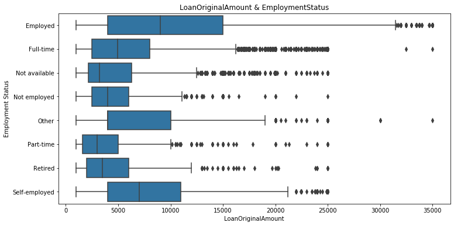

```python
plt.figure(figsize = [12, 6])
sb.boxplot(data=df_loans_clean,x='LoanOriginalAmount',y='EmploymentStatus',color=base_color);
plt.xlabel('LoanOriginalAmount');
plt.ylabel('Employment Status');
plt.title('LoanOriginalAmount & EmploymentStatus');
```

Employed people can get larger loan amounts compared to all other categories

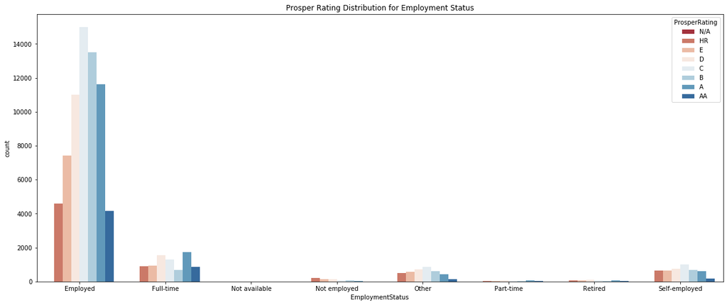

```python
plt.figure(figsize = [20, 8])
sb.countplot(data = df_loans_clean, x = 'EmploymentStatus', hue = 'ProsperRating', palette='RdBu')
plt.title('Prosper Rating Distribution for Employment Status');
```

It is noticed that Employed people get rating C or above while Not Employed recieve mostly HR means High Risk and this makes sense

### Talk about some of the relationships you observed in this part of the investigation. How did the feature(s) of interest vary with other features in the dataset?

> It is noticed that EmploymentStatus and StatedMonthlyIncome affects the main features ProsperScore
- People who are not employed receive low score and high interest rate compared to the employed
- The higher the income, the higher the score and the lower the interest rate

### Did you observe any interesting relationships between the other features (not the main feature(s) of interest)?

- It was observed that EmploymentStatus has a relation with ProsperRating where the un-employed are mostly given a High Risk rating.
- Number of Defaulted loans for Self-employed people are larger than those for Not Employed

**Multivariate analysis**

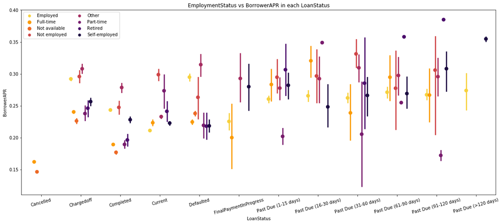

```python
fig = plt.figure(figsize = [20,8])
ax = sb.pointplot(data = df_loans_clean, x = 'LoanStatus', y = 'BorrowerAPR', hue = 'EmploymentStatus', linestyles = "",
                  dodge = 0.5, palette = 'inferno_r')
plt.title('EmploymentStatus vs BorrowerAPR in each LoanStatus')
plt.ylabel('BorrowerAPR')
plt.xticks(rotation=15)
plt.legend(ncol=2)
plt.show();
```

Past Due loans generally have higher interest rates in all employment statuses

```python
# Make a dataframe sorted correctly by quarter

time_series = df_loans_clean.groupby(df_loans_clean['LoanOriginationQuarter']).count().reset_index()

time_series.LoanOriginationQuarter = pd.Categorical(time_series.LoanOriginationQuarter,
                                                    sorted(time_series.LoanOriginationQuarter,
                                                           key=lambda x: x.split(' ')[-1]), ordered = True)
time_series.sort_values('LoanOriginationQuarter', inplace=True)

quarters = time_series['LoanOriginationQuarter'].to_list()
quarters

df = df_loans_clean.copy()

ordinal_var_dict = {'LoanOriginationQuarter': quarters}

ordered_var = pd.api.types.CategoricalDtype(ordered = True, categories = ordinal_var_dict['LoanOriginationQuarter'])
df['LoanOriginationQuarter'] = df['LoanOriginationQuarter'].astype(ordered_var)

## Count Loans by Quarter and Loans Status

cat_counts = df.sort_values(by=['LoanOriginationDate']).groupby(['LoanOriginationQuarter','LoanStatus']).count()['LoanOriginationDate']
cat_counts = cat_counts.reset_index()
cat_counts = cat_counts.rename(columns={'LoanOriginationDate': 'count'})
cat_counts['count'] = cat_counts['count'].fillna(0)
```

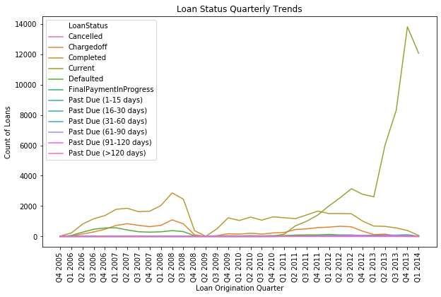

```python
# Plot line chart with each line shows the trend of a Loan Status
plt.figure(figsize = [10, 6])
sb.lineplot(data=cat_counts, x = 'LoanOriginationQuarter', y='count', hue='LoanStatus')
plt.xticks(quarters, rotation = 90)
plt.xlabel('Loan Origination Quarter')
plt.ylabel('Count of Loans')
plt.title('Loan Status Quarterly Trends');
```

Intersting to notice that Defaulted loans decreased after Q4-2008, also Current loans increased rapidly in 2013 (and it is logic that no Current loans before 2011 as the maximum loan term is 5 years)

### Were there any interesting or surprising interactions between features?

> It was important to notice the fact that loans with higher LoanOriginalAmount are mostly taken by people with higher ProsperScore